# Palmer Penguins

Themistoklis Botsas

26/12/2020

# Read the data

The data are derived from the tidytuesday project: https://github.com/rfordatascience/tidytuesday/blob/master/data/2020/2020-07-28/readme.md

```r
penguins <- readr::read_csv('https://raw.githubusercontent.com/rfordatascience/tidytuesday/master/data/2020/2020-07-28/penguins.csv')
```

# Exploratory data analysis (EDA)

Using the package *skimr* we can have a brief overview of the data.

```r
skimr::skim(penguins)
```

Data summary

| Name | penguins |
| --- | --- |
| Number of rows | 344 |
| Number of columns | 8 |
| _______________________ |  |
| Column type frequency: |  |
| character | 3 |
| numeric | 5 |
| ________________________ |  |
| Group variables | None |

**Variable type: character**

| skim_variable | n_missing | complete_rate | min | max | empty | n_unique | whitespace |
| --- | --- | --- | --- | --- | --- | --- | --- |
| species | 0 | 1.00 | 6 | 9 | 0 | 3 | 0 |
| island | 0 | 1.00 | 5 | 9 | 0 | 3 | 0 |
| sex | 11 | 0.97 | 4 | 6 | 0 | 2 | 0 |

**Variable type: numeric**

| skim_variable | n_missing | complete_rate | mean | sd | p0 | p25 | p50 | p75 | p100 | hist |
| --- | --- | --- | --- | --- | --- | --- | --- | --- | --- | --- |
| bill_length_mm | 2 | 0.99 | 43.92 | 5.46 | 32.1 | 39.23 | 44.45 | 48.5 | 59.6 | ▃▇▇▆▁ |
| bill_depth_mm | 2 | 0.99 | 17.15 | 1.97 | 13.1 | 15.60 | 17.30 | 18.7 | 21.5 | ▅▅▇▇▂ |
| flipper_length_mm | 2 | 0.99 | 200.92 | 14.06 | 172.0 | 190.00 | 197.00 | 213.0 | 231.0 | ▂▇▃▅▂ |
| body_mass_g | 2 | 0.99 | 4201.75 | 801.95 | 2700.0 | 3550.00 | 4050.00 | 4750.0 | 6300.0 | ▃▇▆▃▂ |
| year | 0 | 1.00 | 2008.03 | 0.82 | 2007.0 | 2007.00 | 2008.00 | 2009.0 | 2009.0 | ▇▁▇▁▇ |

There are 3 discrete variables; 2 with 3 levels (species and island) and 1 with 2 levels (sex). There are also 5 continuous variables; 4 that refer to physical attributes of the penguins (bill_length_mm, bill_depth_mm, flipper_length_mm and body_mass_g) and the year that each entry was recorded.

The aforementioned data can be used for a variety of analyses. We are going to focus on a **classification** problem based on the species of the penguins.

The year of recording is not useful for our task so we can remove it. Additionally, we should make all discrete features factors.

```r
penguins <- penguins %>%
  select(-year) %>%
  mutate_if(is.character, as.factor)
```

There seem to be some missing values, which we have to address before any further analysis.

## Missing data

Using the package *naniar* we can check the occurance of missing values based on the features.

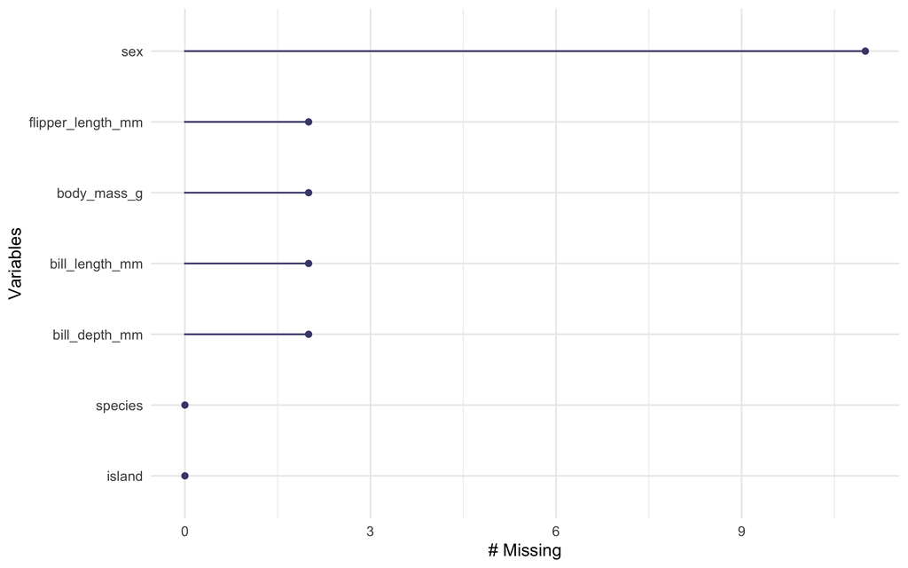

```r
penguins %>%
  gg_miss_var()
```

There seem to be 2 missing values for most features. It would be interesting to see if the refer to the same entries.

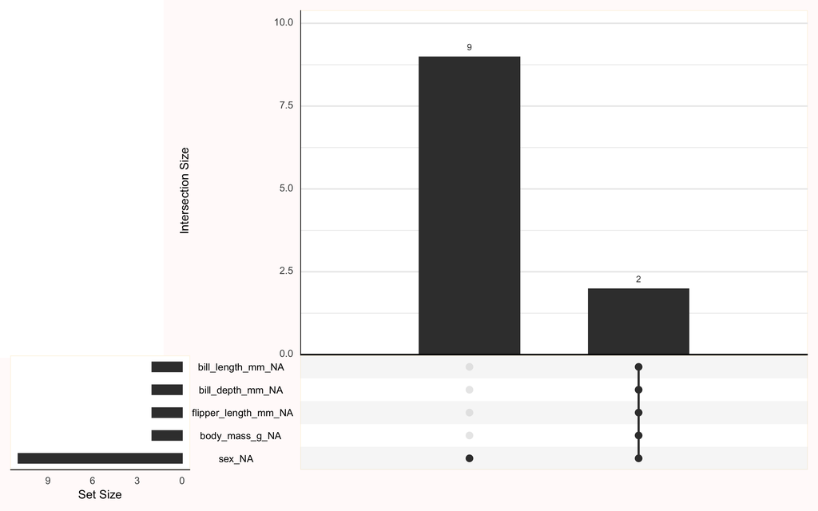

```r
penguins %>%
  gg_miss_upset()
```

Indeed they are. So in total we have 11 entries with missing values (2 entries with 5 missing features plus 9 entries where only the sex feature is missing). Since they are not that many we might as well get rid of them.

```r
penguins <- penguins %>%
  drop_na()
```

## EDA plots

We are going to use the package *GGally* in order to look at the scatteplot, histograms and boxplots of the data setting the color based on the penguins’ species.

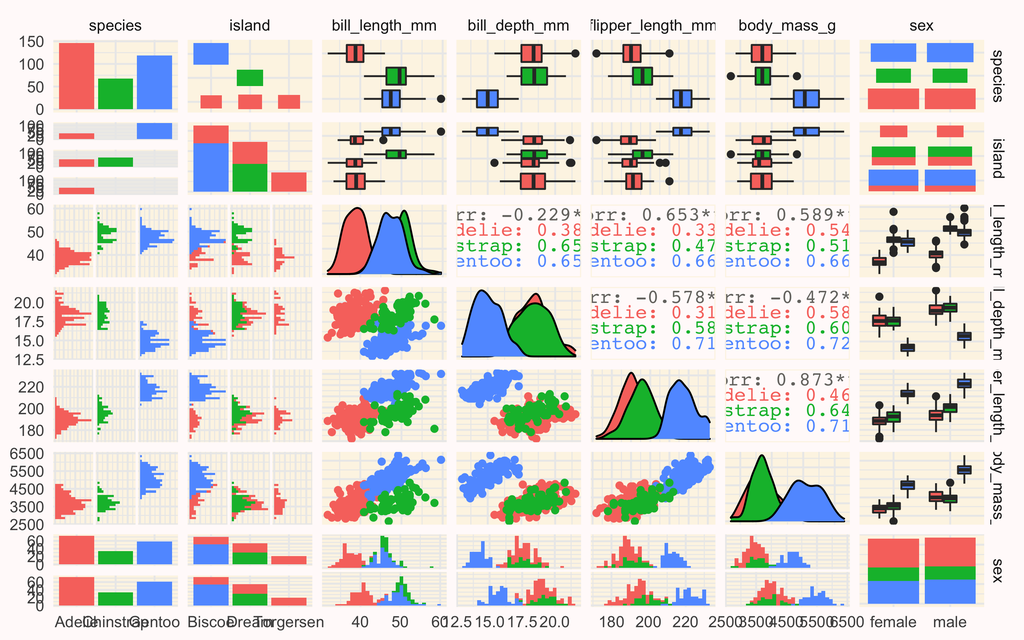

```r
penguins %>% ggpairs(ggplot2::aes(colour=species))
```

We can already see that some features are showing significant differences. For example only Adelie penguins live in more than one islands, Gentoo penguins have lengthier flippers and larger body mass etc.

The boxplots don’t show any extreme outliers so we won’t take any further action.

Finally, let’s look at the correlations of the continuous features using the *corrr* package.

```
##
## Correlation method: 'pearson'
## Missing treated using: 'pairwise.complete.obs'
```

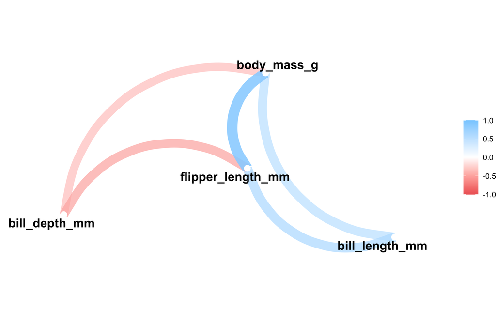

```r
penguins %>% select_if(is.numeric) %>%
  correlate() %>%
  network_plot()
```

It looks like bill_depth_mm is negatively correlated with the rest of the continuous features. This statement agrees with our extracts from the histograms, where is was the only feature where the gentoo penguins score lower values than the other two species.

# Machine learning (ML) model

## Make a train-test routine

```r
set.seed(12)
penguins_split <- initial_split(penguins, strata = sex)
penguins_train <- training(penguins_split)
penguins_test <- testing(penguins_split)
```

## Data preprocessing

This is a simple application, so it does not require any complex preprocessing. It still requires one-hot encoding for all discrete features.

```r
penguins_recipe <- recipe(species ~ ., data = penguins_train) %>%
  step_dummy(all_nominal(), -all_outcomes())
```

## Initialize the model

We are going to use a K-Neirest Neighbours model.

```r
knn_spec <- nearest_neighbor() %>%
  set_engine("kknn") %>%
  set_mode("classification")
```

## Create a workflow (recipe + model)

```r
penguins_wf <- workflow() %>%
  add_recipe(penguins_recipe) %>%
  add_model(knn_spec)

penguins_wf
```

```
## ══ Workflow ════════════════════════════════════════════════════════════════════
## Preprocessor: Recipe
## Model: nearest_neighbor()
##
## ── Preprocessor ────────────────────────────────────────────────────────────────
## 1 Recipe Step
##
## ● step_dummy()
##
## ── Model ───────────────────────────────────────────────────────────────────────
## K-Nearest Neighbor Model Specification (classification)
##
## Computational engine: kknn
```

## Fit the model

```r
knn_fit <- fit(penguins_wf, data = penguins_train)
```

# Model Assessment

## Confusion matrix

```r
knn_fit %>%
    predict(penguins_test) %>%
    bind_cols(penguins_test) %>%
    conf_mat(species, .pred_class)
```

```
##            Truth
## Prediction  Adelie Chinstrap Gentoo
##   Adelie        33         0      0
##   Chinstrap      0        18      0
##   Gentoo         0         0     32
```

```r
#metrics <- metric_set(accuracy, roc_auc)
#knn_final <- last_fit(penguins_wf, penguins_split, metrics = metrics)
#collect_metrics(knn_final)
```

All penguins in the test set were classified correctly…

## Roc curves

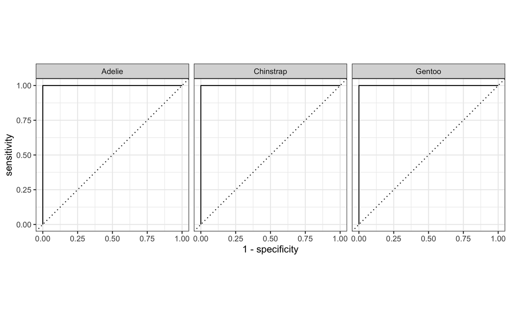

```r
knn_fit %>%
  predict(penguins_train, type = "prob") %>%
  bind_cols(penguins_train) %>%
  roc_curve(species, .pred_Adelie:.pred_Gentoo) %>%
  autoplot()
```